# Viral and bacterial disease trends after COVID-19

Stakeholder report · public health expert

**Question:** How have viral and bacterial infectious diseases in Switzerland developed in the years after COVID (2021-2025)?

*Source: FOPH Infectious Disease Dashboard (IDD) exports, published up to 2026-09-30. National level (CH + FL), all ages, all sexes. Period 2021–2025, reference year 2019.*

## Headline numbers

Viral (excl. COVID-19) vs 2019

**+123%**

2021→2025: +1213%

Bacterial vs 2019

**+23%**

2021→2025: +32%

COVID-19 notifications

**-98%**

peak 2022: 3,045,024

Strongest rise

**Influenza**

+7851% since 2021

## Key findings

- Bacterial notifications changed +32% between 2021 and 2025 and are +23% vs 2019. Main contributors: Shigellosis, Gonorrhoea, Lyme borreliosis.
- Viral notifications excluding COVID-19 changed +1213% between 2021 and 2025.
- Excluding Influenza as well, viral notifications are -4% vs 2019.
- Largest relative increases: Influenza +7851%; Shigellosis +134%; Hepatitis A +74%.
- Largest decreases: COVID-19 * -98%; Hepatitis E -48%.

## Viral vs bacterial, indexed

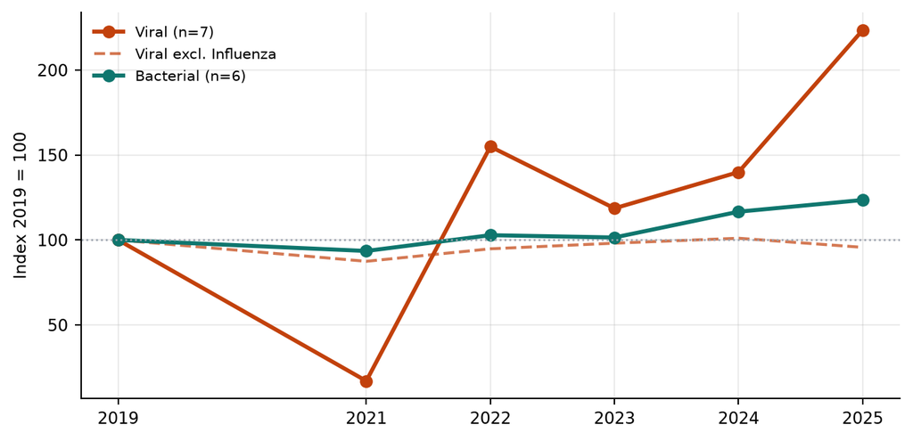

Sum of notified cases per group, pre-COVID base year = 100. Dashed lines also remove the sensitivity-excluded topics (influenza).

## Per disease: incidence per 100,000

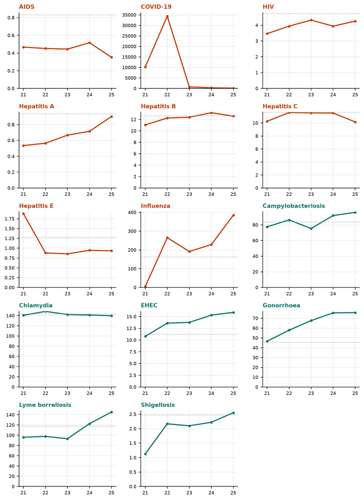

Dotted line = reference-year level. Orange = viral, teal = bacterial.

## Change table

| Disease | Class | 2019 | 2021 | 2022 | 2023 | 2024 | 2025 | 2021→2025 | vs 2019 | per 100k (2025) | Peak | Trend |
| --- | --- | --- | --- | --- | --- | --- | --- | --- | --- | --- | --- | --- |
| AIDS | viral | 72 | 41 | 40 | 40 | 47 | 32 | -22% | -56% | 0.4 | 2024 | falling |
| COVID-19 * | viral | – | 900,839 | 3,045,024 | 67,951 | 28,389 | 13,740 | -98% | – | 151.1 | 2022 | falling |
| HIV | viral | 409 | 304 | 349 | 389 | 358 | 387 | +27% | -5% | 4.3 | 2023 | rising |
| Hepatitis A | viral | 81 | 47 | 50 | 60 | 65 | 82 | +74% | +1% | 0.9 | 2025 | rising |
| Hepatitis B | viral | 1,094 | 969 | 1,086 | 1,116 | 1,199 | 1,144 | +18% | +5% | 12.6 | 2024 | rising |
| Hepatitis C | viral | 1,008 | 900 | 1,027 | 1,040 | 1,048 | 924 | +3% | -8% | 10.2 | 2024 | stable |
| Hepatitis E | viral | 111 | 165 | 78 | 77 | 86 | 85 | -48% | -23% | 0.9 | 2021 | falling |
| Influenza | viral | 14,069 | 440 | 23,466 | 17,253 | 20,766 | 34,984 | +7851% | +149% | 384.8 | 2025 | rising |
| Campylobacteriosis | bacterial | 7,253 | 6,802 | 7,645 | 6,784 | 8,360 | 8,716 | +28% | +20% | 95.9 | 2025 | rising |
| Chlamydia | bacterial | 12,409 | 12,335 | 13,131 | 12,790 | 12,827 | 12,707 | +3% | +2% | 139.8 | 2022 | stable |
| EHEC | bacterial | 970 | 947 | 1,205 | 1,239 | 1,392 | 1,446 | +53% | +49% | 15.9 | 2025 | rising |
| Gonorrhoea | bacterial | 3,942 | 4,088 | 5,127 | 6,091 | 6,868 | 6,894 | +69% | +75% | 75.8 | 2025 | rising |
| Lyme borreliosis | bacterial | 10,155 | 8,402 | 8,621 | 8,354 | 11,101 | 13,158 | +57% | +30% | 145.4 | 2025 | rising |
| Shigellosis | bacterial | 214 | 99 | 192 | 189 | 202 | 232 | +134% | +8% | 2.6 | 2025 | rising |

* excluded from group totals. Rising/falling = change of more than ±15%. Every value is listed with its source file and row in the trace table below.

## Context: GP consultations for respiratory syndromes

Sentinella estimates; mixed viral and bacterial causes, so not assigned to either group.

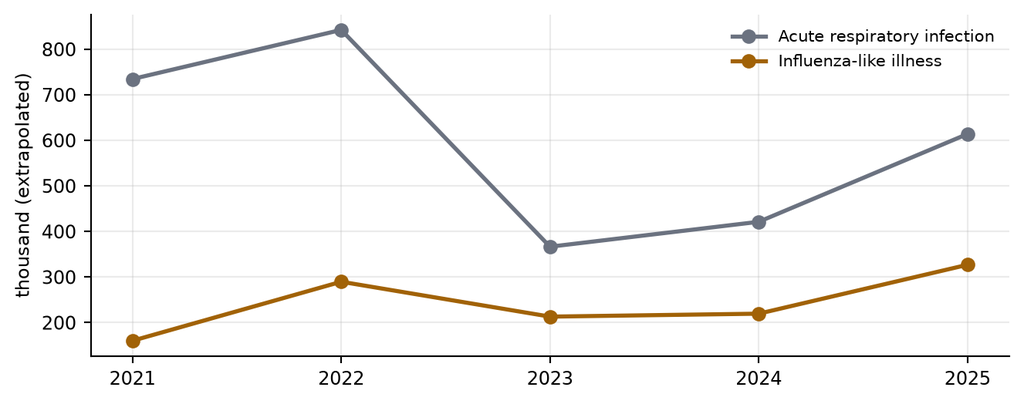

## Datasets not used, and why

| Topic | Class | Reason |
| --- | --- | --- |
| covid19 | viral | no count measure (has: samples_sentinella) |
| respiratory_pathogens | surveillance_signal | no count measure (has: samples) |
| wastewater_sequencing | surveillance_signal | no total rows with values |
| wastewater_viral_load | surveillance_signal | no count measure (has: influenza_a, influenza_b, respiratory_syncytial_virus, sars-cov-2) |

## Data quality

84 checks passed, 0 warnings, 0 failures on the 16 datasets used.

## Sources and traceability

20 unique datasets harmonised; 17 duplicate downloads skipped by file fingerprint.

| topic | source_system | publishing_date | used | file | sha256 | rows |
| --- | --- | --- | --- | --- | --- | --- |
| aids | mandatory | 2026-09-02 | yes | AIDS_oblig/data.csv | 906ec0d77eba | 13.000000 |
| campylobacteriosis | mandatory | 2026-09-09 | yes | CAMPYLOBACTERIOSIS_oblig/data.csv | 19b915920c0f | 755.000000 |
| chlamydiosis | mandatory | 2026-09-02 | yes | CHLAMYDIOSIS_oblig/data.csv | 33301a7f552e | 783.000000 |
| covid19 | swiss pathogen surveillance platform | 2026-09-30 | no | COVID19_genomic_surveillance/data.csv | 8440ae29f194 | 198.000000 |
| covid19 | mandatory | 2026-09-30 | yes | COVID19_oblig/data.csv | 884387436099 | 13501.000000 |
| acute_respiratory_infection | sentinella | 2026-09-30 | yes | COVID19_sentinella/data.csv | 39c3d8533367 | 5229.000000 |
| wastewater_sequencing | swiss federal institute of technology | 2026-09-30 | no | COVID19_wastewater_sequencing/data.csv | ca4ca4fc3a11 | 226596.000000 |
| ehec | mandatory | 2026-09-09 | yes | EHEC_oblig/data.csv | 8f9109a49ed0 | 771.000000 |
| gonorrhea | mandatory | 2026-09-02 | yes | GONORRHEA_oblig/data.csv | e8da3a7b21d8 | 777.000000 |
| hepatitis_a | mandatory | 2026-09-09 | yes | HEPATITIS_A_oblig/data.csv | af364adc8c31 | 745.000000 |
| hepatitis_b | mandatory | 2026-09-02 | yes | HEPATITIS_B_oblig/data.csv | efca8a94f34e | 829.000000 |
| hepatitis_c | mandatory | 2026-09-02 | yes | HEPATITIS_C_oblig/data.csv | dafc82712a52 | 829.000000 |
| hepatitis_e | mandatory | 2026-09-09 | yes | HEPATITIS_E_oblig/data.csv | 9f9612b83428 | 536.000000 |
| hiv | mandatory | 2026-09-02 | yes | HIV_oblig/data.csv | a382cd7fa6bd | 777.000000 |
| influenza | mandatory | 2026-09-30 | yes | INFLUENZA_oblig/data.csv | b99973369aad | 31028.000000 |
| influenza-like_illness | sentinella | 2026-09-30 | yes | INFLUENZA_sentinella/data.csv | 880cad3cb3d9 | 12366.000000 |
| lyme_borreliosis | sentinella | 2026-09-16 | yes | LYME_sentinella/data.csv | 86357493561b | 522.000000 |
| respiratory_pathogens | national reference center for influenza | 2026-09-30 | no | RESPVIRUSES_sentinella/data.csv | 32f85c96135a | 5008.000000 |
| wastewater_viral_load | swiss federal institute of aquatic science and technology | 2026-09-30 | no | RESPVIRUSES_wastewater (3)/data.csv | 98e92f9a9020 | 74580.000000 |
| shigellosis | mandatory | 2026-09-09 | yes | SHIGELLOSIS_oblig/data.csv | f3b6c8f59d39 | 745.000000 |

**Trace: every number back to its source row**

| dataset_id | topic | year | value | source_file | source_row |
| --- | --- | --- | --- | --- | --- |
| acute_respiratory_infection__sentinella_reporting_system__39c3d853 | acute_respiratory_infection | 2020 | 660,144 | COVID19_sentinella/data.csv | 5225 |
| acute_respiratory_infection__sentinella_reporting_system__39c3d853 | acute_respiratory_infection | 2021 | 734,540 | COVID19_sentinella/data.csv | 5226 |
| acute_respiratory_infection__sentinella_reporting_system__39c3d853 | acute_respiratory_infection | 2022 | 842,382 | COVID19_sentinella/data.csv | 5227 |
| acute_respiratory_infection__sentinella_reporting_system__39c3d853 | acute_respiratory_infection | 2023 | 366,559 | COVID19_sentinella/data.csv | 5228 |
| acute_respiratory_infection__sentinella_reporting_system__39c3d853 | acute_respiratory_infection | 2024 | 421,210 | COVID19_sentinella/data.csv | 5229 |
| acute_respiratory_infection__sentinella_reporting_system__39c3d853 | acute_respiratory_infection | 2025 | 613,941 | COVID19_sentinella/data.csv | 5230 |
| aids__mandatory_reporting_system__906ec0d7 | aids | 2019 | 72 | AIDS_oblig/data.csv | 8 |
| aids__mandatory_reporting_system__906ec0d7 | aids | 2020 | 45 | AIDS_oblig/data.csv | 9 |
| aids__mandatory_reporting_system__906ec0d7 | aids | 2021 | 41 | AIDS_oblig/data.csv | 10 |
| aids__mandatory_reporting_system__906ec0d7 | aids | 2022 | 40 | AIDS_oblig/data.csv | 11 |
| aids__mandatory_reporting_system__906ec0d7 | aids | 2023 | 40 | AIDS_oblig/data.csv | 12 |
| aids__mandatory_reporting_system__906ec0d7 | aids | 2024 | 47 | AIDS_oblig/data.csv | 13 |
| aids__mandatory_reporting_system__906ec0d7 | aids | 2025 | 32 | AIDS_oblig/data.csv | 14 |
| campylobacteriosis__mandatory_reporting_system__19b91592 | campylobacteriosis | 2019 | 7,253 | CAMPYLOBACTERIOSIS_oblig/data.csv | 521 |
| campylobacteriosis__mandatory_reporting_system__19b91592 | campylobacteriosis | 2020 | 6,042 | CAMPYLOBACTERIOSIS_oblig/data.csv | 551 |
| campylobacteriosis__mandatory_reporting_system__19b91592 | campylobacteriosis | 2021 | 6,802 | CAMPYLOBACTERIOSIS_oblig/data.csv | 581 |
| campylobacteriosis__mandatory_reporting_system__19b91592 | campylobacteriosis | 2022 | 7,645 | CAMPYLOBACTERIOSIS_oblig/data.csv | 611 |
| campylobacteriosis__mandatory_reporting_system__19b91592 | campylobacteriosis | 2023 | 6,784 | CAMPYLOBACTERIOSIS_oblig/data.csv | 641 |
| campylobacteriosis__mandatory_reporting_system__19b91592 | campylobacteriosis | 2024 | 8,360 | CAMPYLOBACTERIOSIS_oblig/data.csv | 670 |
| campylobacteriosis__mandatory_reporting_system__19b91592 | campylobacteriosis | 2025 | 8,716 | CAMPYLOBACTERIOSIS_oblig/data.csv | 699 |
| chlamydiosis__mandatory_reporting_system__33301a7f | chlamydiosis | 2019 | 12,409 | CHLAMYDIOSIS_oblig/data.csv | 569 |
| chlamydiosis__mandatory_reporting_system__33301a7f | chlamydiosis | 2020 | 11,258 | CHLAMYDIOSIS_oblig/data.csv | 580 |
| chlamydiosis__mandatory_reporting_system__33301a7f | chlamydiosis | 2021 | 12,335 | CHLAMYDIOSIS_oblig/data.csv | 591 |
| chlamydiosis__mandatory_reporting_system__33301a7f | chlamydiosis | 2022 | 13,131 | CHLAMYDIOSIS_oblig/data.csv | 602 |
| chlamydiosis__mandatory_reporting_system__33301a7f | chlamydiosis | 2023 | 12,790 | CHLAMYDIOSIS_oblig/data.csv | 613 |
| chlamydiosis__mandatory_reporting_system__33301a7f | chlamydiosis | 2024 | 12,827 | CHLAMYDIOSIS_oblig/data.csv | 623 |
| chlamydiosis__mandatory_reporting_system__33301a7f | chlamydiosis | 2025 | 12,707 | CHLAMYDIOSIS_oblig/data.csv | 633 |
| covid19__mandatory_reporting_system__88438743 | covid19 | 2020 | 456,443 | COVID19_oblig/data.csv | 13497 |
| covid19__mandatory_reporting_system__88438743 | covid19 | 2021 | 900,839 | COVID19_oblig/data.csv | 13498 |
| covid19__mandatory_reporting_system__88438743 | covid19 | 2022 | 3,045,024 | COVID19_oblig/data.csv | 13499 |

[output cut: 80 more lines]